# Survey cleaning

Rick Gilmore

2023-02-01

## Purpose

This document summarizes the data downloading and cleaning involved in the informal survey of NYU Steinhardt graduate students collected in January and February of 2023.

The survey can be found here:

https://forms.gle/tq8QWq94Ru9M4sfJ9

## Background

Some of survey questions were derived from the Appendix in [(Kardash & Edwards, 2012)](https://doi.org/10.1007/s11251-011-9195-0). We thank these authors for publishing the survey questions in their article so that they could be reused.

Rick Gilmore used these for his [class](https://psu-psychology.github.io/psych-490-reproducibility-2023-spring-notes/survey_01_results.html) in the Spring term of 2023.

Questions about the reproducibility crisis are from [(Baker, 2016)](http://www.nature.com/news/1-500-scientists-lift-the-lid-on-reproducibility-1.19970).

## Set-up

We load the required R packages.

```r
suppressPackageStartupMessages(library("tidyverse")) # for pipe %>%
suppressPackageStartupMessages(library("googledrive"))
suppressPackageStartupMessages(library("magrittr"))
suppressPackageStartupMessages(library("dplyr"))
suppressPackageStartupMessages(library("ggplot2"))
```

## Download data

Download the data file from the spreadsheet generated by the Google Form into a comma-separated value (CSV) file in a local directory called `csv/`.

Authenticate to Google.

```r
googledrive::drive_auth(email = "rick.o.gilmore@gmail.com")
```

```r
if (!dir.exists('csv')) {
  dir.create('csv')
}

csv_fn <- "csv/nyu-steinhardt.csv"

googledrive::drive_download(file = 'NYU Steinhardt Survey (Responses)', path = csv_fn, type = 'csv', overwrite = TRUE)
```

```
## File downloaded:
```

```
## • 'NYU Steinhardt Survey (Responses)'
##   <id: 18Iwev6pzKPpsCdHZOA1lrG_4hKrz_6QzNCZaAlhp9I8>
```

```
## Saved locally as:
```

```
## • 'csv/nyu-steinhardt.csv'
```

## Clean data

Load the data file.

```r
if (file.exists(csv_fn)) {
  survey <- readr::read_csv(csv_fn, show_col_types = FALSE)
} else {
  message("File not found: ", csv_fn)
  survey <- NULL
}
```

### Extract specific questions

```r
if (is.null(survey)) {
  warning("Error loading data file")
} else {
  names(survey)
}
```

```
##  [1] "Timestamp"
##  [2] "Have you heard of the \"reproducibility crisis\" in science?"
##  [3] "Is there a reproducibility crisis in your area of research?"
##  [4] "Scientists are generally motivated by the desire for knowledge and discovery, and not by the possibility of personal gain."
##  [5] "Scientists make an attempt to consider all new evidence, hypotheses, theories, and innovations, even those that challenge or contradict their own work."
##  [6] "Scientists generally assess new knowledge and its applications based on the reputation and past productivity of the individual or research group."
##  [7] "Scientists openly share new findings with all colleagues."
##  [8] "Scientists generally invest their careers in promoting their own most important findings, theories, or innovations."
##  [9] "Scientists compete with others in the same field for funding and recognition of their achievements."
## [10] "Scientists generally evaluate research only on its merit (i.e., according to accepted standards of the field)."
## [11] "Scientists emphasize the protection of their newest findings to ensure priority in publishing, patenting, or applications."
## [12] "(Optional) Comments or contact info for follow-up"
```

These variable names are too long to be useful. Let’s look at the source publication [(Kardash & Edwards, 2012)](https://doi.org/10.1007/s11251-011-9195-0) to see if we can simplify them in a useful way.

So, the Appendix labels each question with a short phrase and notes whether the concept is a norm (N) or counter-norm (CN). Let’s rename the variables using the single words.

```r
new_names <-
  c(
    "Timestamp",
    "heardof_reproducibility_crisis",
    "my_area_reproducibility_crisis",
    "disinterestedness",
    "organized skepticism",
    "particularism",
    "communality",
    "organized dogmatism",
    "self-interestedness",
    "universalism",
    "solitariness",
    "Comments"
  )

# Make new data frame with long and short names for reference
survey_qs <- tibble(q_long = names(survey), q_short = new_names)

# Swap out old (long) names for new (short) names
names(survey) <- new_names
```

```r
survey_qs %>%
  kableExtra::kable(., format='html', caption="Survey questions")
```

Survey questions

| q_long | q_short |
| --- | --- |
| Timestamp | Timestamp |
| Have you heard of the "reproducibility crisis" in science? | heardof_reproducibility_crisis |
| Is there a reproducibility crisis in your area of research? | my_area_reproducibility_crisis |
| Scientists are generally motivated by the desire for knowledge and discovery, and not by the possibility of personal gain. | disinterestedness |
| Scientists make an attempt to consider all new evidence, hypotheses, theories, and innovations, even those that challenge or contradict their own work. | organized skepticism |
| Scientists generally assess new knowledge and its applications based on the reputation and past productivity of the individual or research group. | particularism |
| Scientists openly share new findings with all colleagues. | communality |
| Scientists generally invest their careers in promoting their own most important findings, theories, or innovations. | organized dogmatism |
| Scientists compete with others in the same field for funding and recognition of their achievements. | self-interestedness |
| Scientists generally evaluate research only on its merit (i.e., according to accepted standards of the field). | universalism |
| Scientists emphasize the protection of their newest findings to ensure priority in publishing, patenting, or applications. | solitariness |
| (Optional) Comments or contact info for follow-up | Comments |

These data are ‘wide’, meaning that there are multiple variables for each respondent. The data will be easier to visualize and analyze if we make the data ‘longer’.

```r
survey_long <- survey %>%
  tidyr::pivot_longer(
    .,!c(
      'Timestamp',
      'Comments',
      'heardof_reproducibility_crisis',
      'my_area_reproducibility_crisis'
    ),
    names_to = "norm_counternorm",
    values_to = "rating"
  )
```

We should indicate whether these are norms, and label them “Norm”, or counter-norms, and label them “Counternorm”.

```r
survey_long <- survey_long %>%
  dplyr::mutate(., type = if_else(
    norm_counternorm %in% c(
      "disinterestedness",
      "organized skepticism",
      "communality",
      "universalism"
    ),
    "norm",
    "counternorm"
  ))
```

Finally, there is a “test” set of responses that I used to test this data processing workflow. We should delete those responses since they are nonsensical–I just hit random buttons to make some data.

```r
survey_long_clean <- survey_long %>%
  dplyr::filter(., is.na(Comments)) %>%
  dplyr::filter(., !str_detect(Comments, "rog1"))
```

## Visualize data

### Unique respondents

There appear to be $n=$ 11 respondents as of 2023-02-01 08:14:10.

### Reproducibility crisis

> ‘Have you heard of the “reproducibility crisis” in science??’

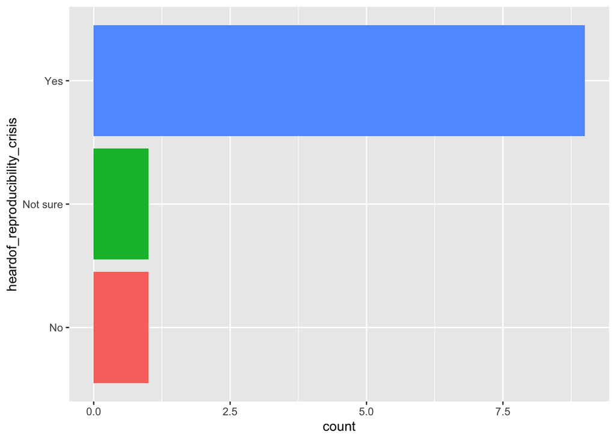

Have you heard of the ‘reproducibility crisis’ in science?

```r
survey %>%
  dplyr::filter(., !is.na(heardof_reproducibility_crisis)) %>%
  ggplot2::ggplot() +
  ggplot2::aes(heardof_reproducibility_crisis, fill = heardof_reproducibility_crisis) +
  ggplot2::geom_bar() +
  ggplot2::theme(legend.position = "none") +
  coord_flip()
```

> ‘Is there a reproducibility crisis in your area of research??’

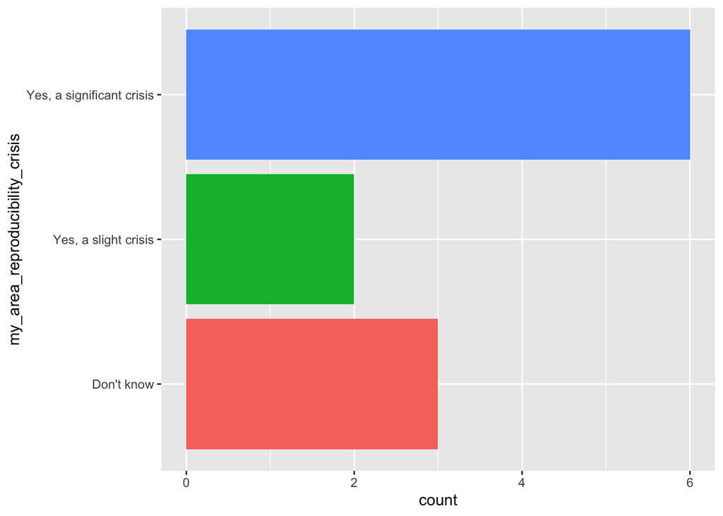

Is there a reproducibility crisis in your area of research?

```r
survey %>%
  dplyr::mutate(., my_area_reproducibility_crisis = factor(
    my_area_reproducibility_crisis,
    c("Don't know", "No, there is no crisis", "Yes, a slight crisis", "Yes, a significant crisis")
  )) %>%
  dplyr::filter(., !is.na(my_area_reproducibility_crisis)) %>%
  ggplot2::ggplot() +
  ggplot2::aes(my_area_reproducibility_crisis, fill = my_area_reproducibility_crisis) +
  ggplot2::geom_bar() +
  ggplot2::theme(legend.position = "none") +
  coord_flip()
```

### Norm/Counternorm Rating distribution

Remember, the rating scale was from 1: “not at all” to 5: “a great deal”.

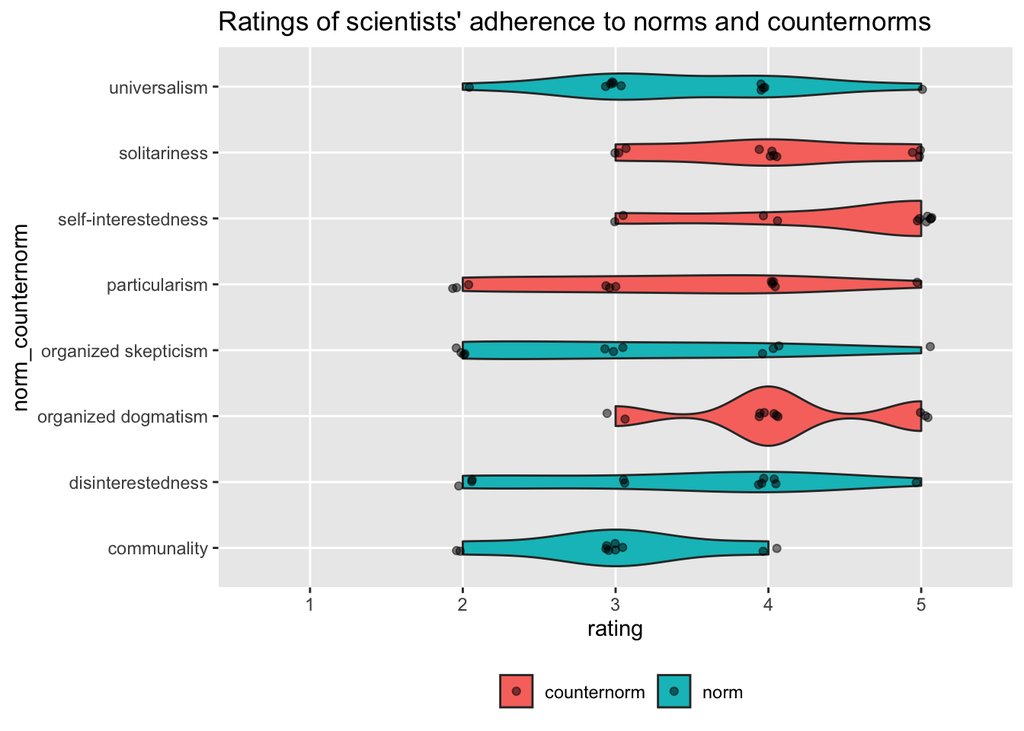

```r
survey_long %>%
  ggplot() +
  aes(norm_counternorm, rating, fill = type) +
  geom_violin() +
  geom_point(position = position_jitter(width = .07, height = .07), alpha = 0.5) +
#  xlim(1,5) +
  scale_y_discrete(limits = c("1", "2", "3", "4", "5")) +
  coord_flip() +
  ggtitle("Ratings of scientists' adherence to norms and counternorms") +
  theme(legend.position = "bottom") +
  theme(legend.title = element_blank())
```

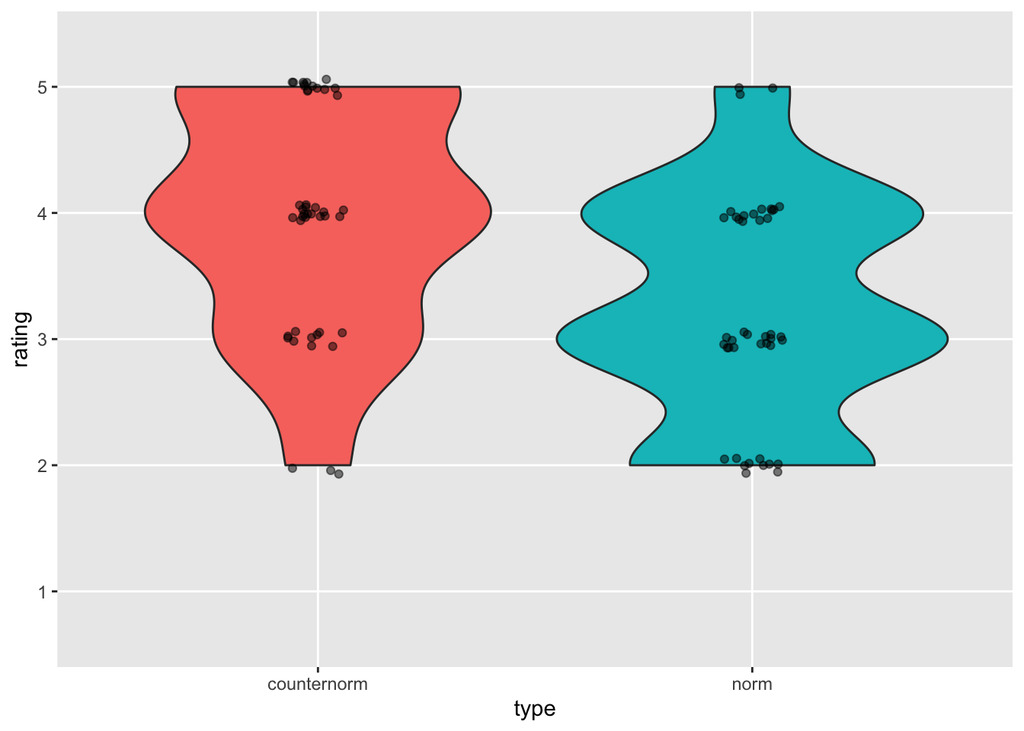

```r
survey_long %>%
  ggplot() +
  aes(type, rating, fill = type) +
  geom_violin() +
  geom_point(position = position_jitter(width = .07, height = .07), alpha = 0.5) +
  scale_y_discrete(limits = c("1", "2", "3", "4", "5")) +
  theme(legend.position = "none")
```

## References

Baker, M. (2016). 1,500 scientists lift the lid on reproducibility. *Nature News*, *533*(7604), 452. https://doi.org/10.1038/533452a

Kardash, C. M., & Edwards, O. V. (2012). Thinking and behaving like scientists: Perceptions of undergraduate science interns and their faculty mentors. *Instructional Science*, *40*(6), 875–899. https://doi.org/10.1007/s11251-011-9195-0